# Documentation

Published

June 18, 2023

## 1 Introduction

Following research is devoted to replication and enhancement of the econometric project within new programming language. The original project, we have taken under consideration, was an econometric research work of Jarosław Leski from 2021 devoted to explaining infant mortality rate across countries. In our novel approach, we have revised the code and rewritten it into Python. Following document is structured as followed: first section presents the results of the model obtained in the original approach, followed by second section devoted to results of the project replication in Python and thorough explanation of source of differences. Finally third section covers enhancements of the model, containing script automating the process of model variables selection.

## 2 Source work results

In order to reproduce the source work of 2021 for classes in the subject of Econometrics, the results of which are as follows:

```
=====================================================================
                                             Dependent variable:
                                        -----------------------------
                                        smiertelnosc wsrod noworodkow
---------------------------------------------------------------------
log GDP                                           -0.410***
                                                   (0.044)

log GDP per capita                                0.104***
                                                   (0.032)

log populacji                                     -0.521***
                                                   (0.102)

log wydatkow panstwa na ochrone zdrowia           -0.154***
                                                   (0.039)

log liczby turystow                                0.217**
                                                   (0.089)

% ludzi mieszkajacych w miastach                  7.489***
                                                   (0.473)

---------------------------------------------------------------------
Observations                                         123
R2                                                  0.841
Adjusted R2                                         0.834
Residual Std. Error                           0.398 (df = 117)
F Statistic                               123.463*** (df = 5; 117)
=====================================================================
Note:                                     *p<0.1; **p<0.05; ***p<0.01
```

## 3 Reproduced work results

in the first step, we decided to reproduce the code 1:1 in Python so as to try to get as identical results as possible

The detailed code can be found in our repository in the file https://github.com/michal-kunstler/RR_project_JD_JR_MK/python_replication.ipynb. In this document, we will focus only on the most important conclusions of the analysis.

OLS Regression Results

| Dep. Variable: | l_noworodki | R-squared: | 0.803 |
| --- | --- | --- | --- |
| Model: | OLS | Adj. R-squared: | 0.795 |
| Method: | Least Squares | F-statistic: | 97.29 |
| Date: | Sun, 18 Jun 2023 | Prob (F-statistic): | 2.36e-40 |
| Time: | 21:52:16 | Log-Likelihood: | -75.436 |
| No. Observations: | 125 | AIC: | 162.9 |
| Df Residuals: | 119 | BIC: | 179.8 |
| Df Model: | 5 |  |  |
| Covariance Type: | nonrobust |  |  |

|  | coef | std err | t | P>\|t\| | [0.025 | 0.975] |
| --- | --- | --- | --- | --- | --- | --- |
| const | 7.6734 | 0.508 | 15.108 | 0.000 | 6.668 | 8.679 |
| l_GDPpc | -0.4050 | 0.051 | -8.003 | 0.000 | -0.505 | -0.305 |
| l_populacja | 0.0965 | 0.035 | 2.753 | 0.007 | 0.027 | 0.166 |
| l_ochrona_zdrowia | -0.3618 | 0.111 | -3.267 | 0.001 | -0.581 | -0.142 |
| l_turysci | -0.1814 | 0.043 | -4.175 | 0.000 | -0.267 | -0.095 |
| HIV | 0.2305 | 0.096 | 2.404 | 0.018 | 0.041 | 0.420 |

| Omnibus: | 1.457 | Durbin-Watson: | 2.164 |
| --- | --- | --- | --- |
| Prob(Omnibus): | 0.483 | Jarque-Bera (JB): | 0.990 |
| Skew: | -0.164 | Prob(JB): | 0.609 |
| Kurtosis: | 3.287 | Cond. No. | 299. |

Notes:  
[1] Standard Errors assume that the covariance matrix of the errors is correctly specified.

Despite our efforts, it was not possible to perfectly replicate the estimated results. We believe this is most likely due to the source study’s method of removing rows based on indices from the Residuals vs Leverage plot. When transcribing the code to Python and utilizing the get_influence function, the code points to indices of completely different observations than those in the original code. We decided to stick with the removal of the original observation indices.

## 4 Enhanced approach to the topic

Upon acquiring advanced econometric and programming skills during our master’s studies, we decided to enhance the code written over two years ago, aiming for maximum automation and improved econometric accuracy.

Please note that our primary intention was not to perfect this model in terms of the approach taken, such as using superior or more recent data, or potentially more suitable models like panel data models. Our primary objective in devising this approach was automation and reproducibility of results, and we primarily directed our attention towards these aspects.

In the initial step, we computed the Variance Inflation Factor (VIF) and eliminated collinear variables, with VIF over 10 from the model.

Despite the VIF coefficient being relatively low, we considered that the values for GDP and GDP per capita should not both remain in the model, as they are most likelu highly correlated. Consequently, we also removed the GDP variable.

````markdown
```{python}
def calculate_vif(Xx):
    vif_data = pd.DataFrame()
    vif_data["feature"] = Xx.columns
    vif_data["VIF"] = [variance_inflation_factor(Xx.values, i)
                            for i in range(len(Xx.columns))]
    lider = vif_data.sort_values(by = 'VIF', ascending= False).iloc[0,]
    print(lider, vif_data)
    if (lider.VIF > 10):
        col = lider.feature
        Xx = Xx.drop(columns= [col])
        calculate_vif(Xx)


vif_data = calculate_vif(Xx)

print(vif_data)
df = df.drop(columns = ['ochrona_zdrowia',  'labor_force'])
df = df.drop(columns = ['GDP'])
```
````

```
feature    labor_force
VIF          30.624501
Name: 5, dtype: object            feature        VIF
0        noworodki   2.789237
1  ochrona_zdrowia  12.060030
2            GDPpc   3.129436
3              GDP   3.451977
4        populacja  26.720347
5      labor_force  30.624501
6       death_rate   8.099559
7        urban_pop   9.358728
8          turysci   2.703658
9              HIV   2.297961
feature    ochrona_zdrowia
VIF              11.856304
```

[output cut: 22 more lines]

Subsequently, prior to the logarithmization of numerical variables, we calculated the values of the Shapiro-Wilk test for variables both before and after logarithmization. We retained in our database those variables for which the p-value was higher (comparing before versus after logarithmization). This is done, because the Shapiro-Wilk test verifies how close a given distribution is to a normal distribution. We assume, that the higher the p-value the closer the distribution to a normal distribution, with our goal being to achieve a distribution as close to normal as possible.

````markdown
```{python}
# shapiro test for pre-log variables
statss = []
for column in df.columns:
  stat, p = shapiro(df[column])
  print('Shapiro-Wilk for {}: {:.3f}, p-value: {:.3f}'.format(column, stat, p))
  statss.append(p)

# shapiro test for logged variables
def logsy(df, cols=[]):
    for col in cols:
        df['log_'+str(col)] = np.log(df[col])
        df = df.drop(columns=[col])
    return df


print(f'-'*50)

df1 = df.copy()
cols = df1.columns
df1 = logsy(df1,cols)

statss1 = []
for column in df1.columns:
  stat, p = shapiro(df1[column])
  print('Shapiro-Wilk for {}: {:.3f}, p-value: {:.3f}'.format(column, stat, p))
  statss1.append(p)
```
````

```
Shapiro-Wilk for noworodki: 0.790, p-value: 0.000
Shapiro-Wilk for GDPpc: 0.756, p-value: 0.000
Shapiro-Wilk for populacja: 0.241, p-value: 0.000
Shapiro-Wilk for death_rate: 0.973, p-value: 0.008
Shapiro-Wilk for urban_pop: 0.965, p-value: 0.001
Shapiro-Wilk for turysci: 0.608, p-value: 0.000
Shapiro-Wilk for HIV: 0.605, p-value: 0.000
--------------------------------------------------
Shapiro-Wilk for log_noworodki: 0.970, p-value: 0.004
Shapiro-Wilk for log_GDPpc: 0.979, p-value: 0.033
Shapiro-Wilk for log_populacja: 0.990, p-value: 0.420
Shapiro-Wilk for log_death_rate: 0.934, p-value: 0.000
Shapiro-Wilk for log_urban_pop: 0.897, p-value: 0.000
Shapiro-Wilk for log_turysci: 0.980, p-value: 0.042
Shapiro-Wilk for log_HIV: nan, p-value: 1.000
```

Following that, we created code which automatically carries out a general-to-specific procedure for the processed database, thereby deriving the final form of the model:

````markdown
```{python}
models = {}
models_summary = {}
drop_order = ['Intercept']
def GTS_iter(df):
    X = df3.drop(columns=['log_noworodki'])
    y = df3['log_noworodki']

    def model_creator(X,y):
        string = ''
        for col in X.columns:
            string = string + str(col) + '+'
        return str(y.name)+'~' + string[:-1]

    model_formula = model_creator(X,y)
    X["log_noworodki"] = y
    model= smf.ols(model_formula , X).fit()

    return(model)

model = GTS_iter(df3)
models['model_1'] = model
models_summary['model_1'] = model.summary()
i = 1

while model.pvalues.max() > 0.05:
    i+=1
    max_pvalue = model.pvalues.idxmax()
    if((max_pvalue == 'Intercept')):
        if((model.pvalues.sort_values(ascending = False)[1] > 0.05)):
            max_pvalue = model.pvalues.sort_values(ascending = False).index[1]
        else:
            break
    df3 = df3.drop(columns=[max_pvalue], axis = 1)
    drop_order.append(max_pvalue)
    model = GTS_iter(df3)
    models_summary[f'model_{i}'] = model.summary()
    models[f'model_{i}'] = model

for col in df3.drop(columns=["log_noworodki"]).columns:
    drop_order.append(col)
```
````

For which, we subsequently conducted diagnostic tests and due to the issue of heteroskedasticity of residuals in the model, we applied a robust covariance matrix:

```
--------------------------------------------------
BP TEST:
 [('Lagrange multiplier statistic', 20.224680836172503), ('p-value', 0.001134020414210504), ('f-value', 4.546245389467839), ('f p-value', 0.0007504683122038339)]
--------------------------------------------------
RESET TEST:
 <Wald test (chi2): statistic=6.0579228999369255, p-value=0.04836584239887944, df_denom=2>
--------------------------------------------------
Jarque Bera TEST:
 SignificanceResult(statistic=0.4959218571910294, pvalue=0.7803904336326688)
```

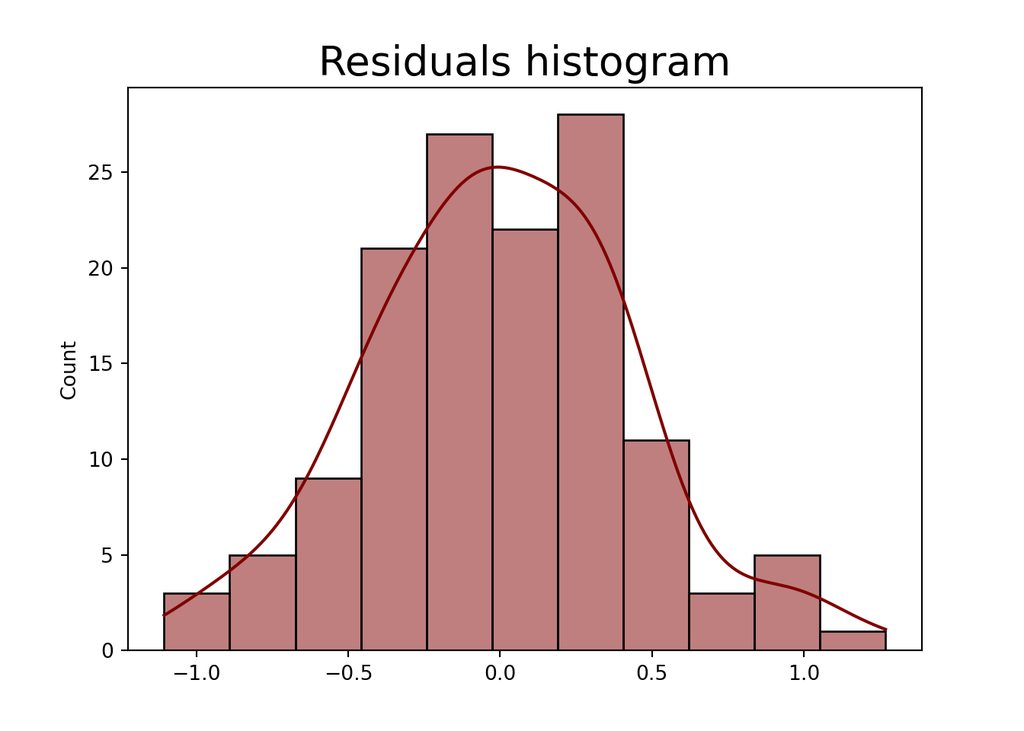

```
                            OLS Regression Results
==============================================================================
Dep. Variable:          log_noworodki   R-squared:                       0.812
Model:                            OLS   Adj. R-squared:                  0.805
Method:                 Least Squares   F-statistic:                     111.6
Date:                Sun, 18 Jun 2023   Prob (F-statistic):           4.20e-45
Time:                        21:52:25   Log-Likelihood:                -79.569
No. Observations:                 135   AIC:                             171.1
Df Residuals:                     129   BIC:                             188.6
Df Model:                           5
Covariance Type:            nonrobust
=================================================================================
                    coef    std err          t      P>|t|      [0.025      0.975]
---------------------------------------------------------------------------------
Intercept         7.7539      0.492     15.773      0.000       6.781       8.726
log_GDPpc        -0.4494      0.046     -9.702      0.000      -0.541      -0.358
log_populacja     0.0922      0.034      2.711      0.008       0.025       0.159
death_rate       -0.0562      0.013     -4.200      0.000      -0.083      -0.030
log_turysci      -0.1717      0.042     -4.120      0.000      -0.254      -0.089
HIV               0.2655      0.093      2.865      0.005       0.082       0.449
==============================================================================
Omnibus:                        0.862   Durbin-Watson:                   2.162
Prob(Omnibus):                  0.650   Jarque-Bera (JB):                0.496
Skew:                           0.107   Prob(JB):                        0.780
Kurtosis:                       3.206   Cond. No.                         322.
==============================================================================

Notes:
[1] Standard Errors assume that the covariance matrix of the errors is correctly specified.
                            OLS Regression Results
==============================================================================
Dep. Variable:          log_noworodki   R-squared:                       0.812
Model:                            OLS   Adj. R-squared:                  0.805
Method:                 Least Squares   F-statistic:                     145.6
Date:                Sun, 18 Jun 2023   Prob (F-statistic):           2.82e-51
Time:                        21:52:25   Log-Likelihood:                -79.569
No. Observations:                 135   AIC:                             171.1
Df Residuals:                     129   BIC:                             188.6
Df Model:                           5
Covariance Type:                  HC1
=================================================================================
                    coef    std err          t      P>|t|      [0.025      0.975]
---------------------------------------------------------------------------------
Intercept         7.7539      0.462     16.793      0.000       6.840       8.667
log_GDPpc        -0.4494      0.043    -10.365      0.000      -0.535      -0.364
log_populacja     0.0922      0.036      2.564      0.011       0.021       0.163
death_rate       -0.0562      0.013     -4.193      0.000      -0.083      -0.030
log_turysci      -0.1717      0.039     -4.457      0.000      -0.248      -0.095
HIV               0.2655      0.094      2.838      0.005       0.080       0.451
==============================================================================
Omnibus:                        0.862   Durbin-Watson:                   2.162
Prob(Omnibus):                  0.650   Jarque-Bera (JB):                0.496
Skew:                           0.107   Prob(JB):                        0.780
Kurtosis:                       3.206   Cond. No.                         322.
==============================================================================

Notes:
[1] Standard Errors are heteroscedasticity robust (HC1)
```

````markdown
```{python}
### diagnostics

final_model = list(models.values())[-1]
name = ["Lagrange multiplier statistic", "p-value", "f-value", "f p-value"]
test = sms.het_breuschpagan(final_model.resid, final_model.model.exog)
print(str('-')*50,'\nBP TEST:\n' , lzip(name, test))
print(str('-')*50,'\nRESET TEST:\n' ,ssd.linear_reset(final_model, power=3, test_type='fitted', use_f=False, cov_type='nonrobust', cov_kwargs=None))
print(str('-')*50,'\nJarque Bera TEST:\n' ,scys.jarque_bera(final_model.resid))
x = sns.histplot(final_model.resid, log_scale=False, kde=True, color='maroon')
x.set_title('Residuals histogram', fontdict={'fontsize':20})
plt.show()

### Roboust matrix
cov_matrix = sm.stats.sandwich_covariance.cov_white_simple(final_model, use_correction=True)

robust_results = final_model.get_robustcov_results(cov_type='HC1')

print(final_model.summary())
print(robust_results.summary())
```
````

Below, results for the models can be found.

**restults for the inital model**

```
                            OLS Regression Results
==============================================================================
Dep. Variable:          log_noworodki   R-squared:                       0.812
Model:                            OLS   Adj. R-squared:                  0.805
Method:                 Least Squares   F-statistic:                     111.6
Date:                Sun, 18 Jun 2023   Prob (F-statistic):           4.20e-45
Time:                        21:52:26   Log-Likelihood:                -79.569
No. Observations:                 135   AIC:                             171.1
Df Residuals:                     129   BIC:                             188.6
Df Model:                           5
Covariance Type:            nonrobust
=================================================================================
                    coef    std err          t      P>|t|      [0.025      0.975]
---------------------------------------------------------------------------------
Intercept         7.7539      0.492     15.773      0.000       6.781       8.726
log_GDPpc        -0.4494      0.046     -9.702      0.000      -0.541      -0.358
log_populacja     0.0922      0.034      2.711      0.008       0.025       0.159
death_rate       -0.0562      0.013     -4.200      0.000      -0.083      -0.030
log_turysci      -0.1717      0.042     -4.120      0.000      -0.254      -0.089
HIV               0.2655      0.093      2.865      0.005       0.082       0.449
==============================================================================
Omnibus:                        0.862   Durbin-Watson:                   2.162
Prob(Omnibus):                  0.650   Jarque-Bera (JB):                0.496
Skew:                           0.107   Prob(JB):                        0.780
Kurtosis:                       3.206   Cond. No.                         322.
==============================================================================

Notes:
[1] Standard Errors assume that the covariance matrix of the errors is correctly specified.
```

**results for the model with robust VCov matrix applied**

```
                            OLS Regression Results
==============================================================================
Dep. Variable:          log_noworodki   R-squared:                       0.812
Model:                            OLS   Adj. R-squared:                  0.805
Method:                 Least Squares   F-statistic:                     145.6
Date:                Sun, 18 Jun 2023   Prob (F-statistic):           2.82e-51
Time:                        21:52:27   Log-Likelihood:                -79.569
No. Observations:                 135   AIC:                             171.1
Df Residuals:                     129   BIC:                             188.6
Df Model:                           5
Covariance Type:                  HC1
=================================================================================
                    coef    std err          t      P>|t|      [0.025      0.975]
---------------------------------------------------------------------------------
Intercept         7.7539      0.462     16.793      0.000       6.840       8.667
log_GDPpc        -0.4494      0.043    -10.365      0.000      -0.535      -0.364
log_populacja     0.0922      0.036      2.564      0.011       0.021       0.163
death_rate       -0.0562      0.013     -4.193      0.000      -0.083      -0.030
log_turysci      -0.1717      0.039     -4.457      0.000      -0.248      -0.095
HIV               0.2655      0.094      2.838      0.005       0.080       0.451
==============================================================================
Omnibus:                        0.862   Durbin-Watson:                   2.162
Prob(Omnibus):                  0.650   Jarque-Bera (JB):                0.496
Skew:                           0.107   Prob(JB):                        0.780
Kurtosis:                       3.206   Cond. No.                         322.
==============================================================================

Notes:
[1] Standard Errors are heteroscedasticity robust (HC1)
```

The initial testing of the model revealed that there is a problem with heteroskedasticity. The result from the BP test is a p-value of <5%, meaning that there is sufficient evidence to reject the null hypothesis stating that the model is homeostatic. Furthermore, RESET test returns a p-value of <5%, meaning that the functional form of the model is not proper. This suggests that the relationship modeled here is probably not linear hence the model based on OLS is of limited use. The Jarque-Bera test returns a p-value over 5%, meaning that the distribution of the residuals is normal or close to normal.

Furthermore, after applying a robust VCov matrix, all of the estimates are individually significant and the model overall is significant (as shown by the p-value of the F-test being below 5%).